# HW1 - Tidycensus Markdown (Resubmit)

## b. A ggplot map

Map a ggplot map symbolizing the number of vacant housing units in 2016 as a percentage of total housing units (e.g. “total_HU.2016”) on a per-tract basis. Outline the Mt. Airy neighborhood on the map. Annotate this map with a single sentence describing what it shows or implies about Mt Airy and Philadelphia.

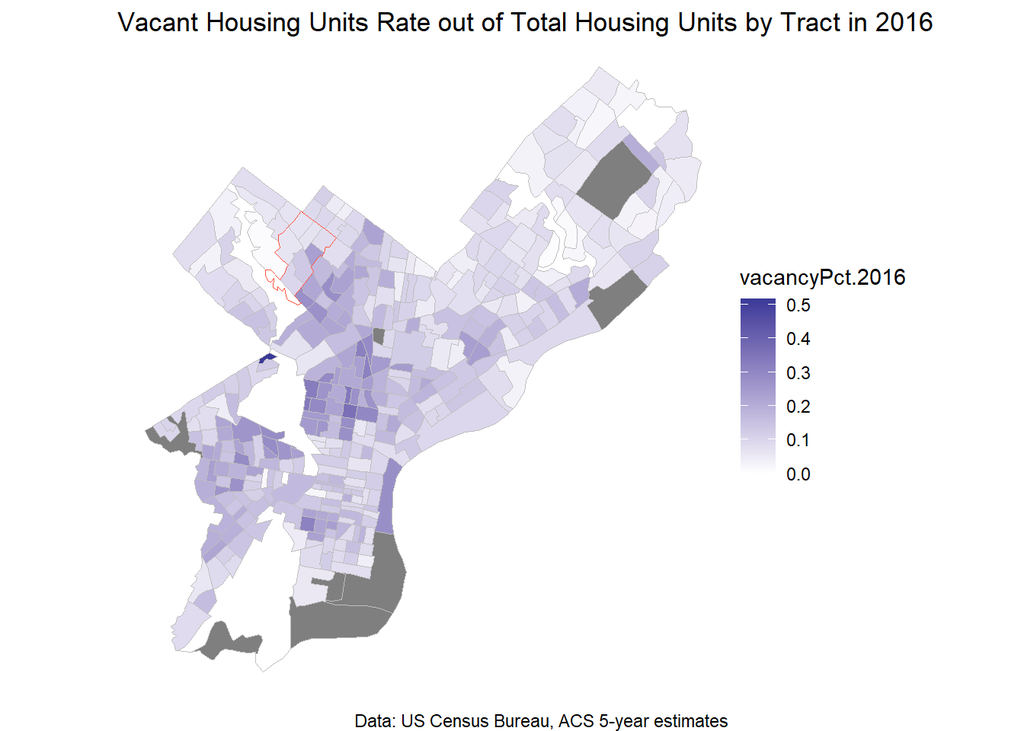

```r
ggplot()+
  geom_sf(data = acsTractsPHL.2016.sf, aes(fill = vacancyPct.2016),
          color = "gray")+
  scale_fill_gradient2(midpoint = 0.0) +
  geom_sf(data = acsTractsPHL.2016.sf %>%
            filter(mtAiry == "MT AIRY") %>%
            st_union(),
          color = "#FF5440",
          fill = "transparent")+
  labs(
    title = "Vacant Housing Units Rate out of Total Housing Units by Tract in 2016",
    caption = "Data: US Census Bureau, ACS 5-year estimates") +
  theme_void()
```

### Single Sentence Explanation

According to the map, the vacancy rate of the Mt. Airy area in 2016 was lower than the north-central and southwest of Philadelphia County, and some tracts southeast of Mt. Airy are higher than the north of Mt. Airy area.

## c. Summary Table

```r
summaryTable3 <- allACS %>%
  group_by(mtAiry) %>%
  summarize(mean_total_vacant_2020 = mean(total_vacant.2020, na.rm = TRUE))

summaryTable3 %>%
  kbl(caption = "Mean Number of Vacant Housing Units per Tract in 2020",
      col.names = c("AREA", "MEAN")) %>%
  kable_styling(position="center") %>%
  kable_classic(full_width = T, html_font = "Arial")
```

Mean Number of Vacant Housing Units per Tract in 2020

| AREA | MEAN |
| --- | --- |
| MT AIRY | 156.625 |
| REST OF PHILADELPHIA | 196.893 |

### Single Sentence Explanation

Mt. Airy’s mean number of vacant housing units per tract is 156.625, lower than the rest of Philadelphia County’s mean of 196.893.